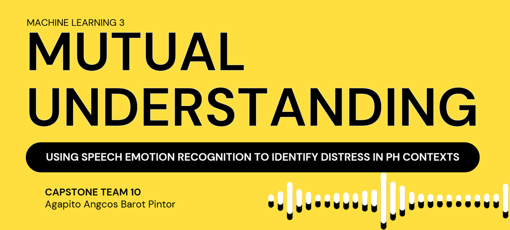

# INTRODUCTION

The intricate nuances of human emotions conveyed through speech pose a compelling challenge for artificial intelligence (AI) systems. The ability to understand and respond to these underlying emotional states is a fascinating prospect that opens up a world of possibilities, particularly in the realm of automatic customer-facing systems. Imagine a future where AI virtual assistants possess the remarkable ability to not only comprehend the words we speak but also grasp the emotions behind them. This vision has sparked the exploration of speech emotion recognition technology, paving the way for more personalized and empathetic interactions with AI.

In this report, titled "Mutual Understanding: Using Speech Emotion Recognition to Identify Distress in Philippine Contexts," we embark on a journey into the localization of speech emotion recognition technology in the Philippine context.

## Can AI Grasp the Complexity of Human Emotions in Speech?

Just imagine a future where advanced AI virtual assistants possess the extraordinary ability to not only understand the words we speak but also decipher the underlying emotional states behind them. Envision an emergency hotline operated by AI, capable of offering compassionate responses and skillfully diffusing tense situations with a profound understanding of human emotions.

While strides have been made in speech emotion recognition technology, primarily focusing on English-based datasets and linguistic patterns, adapting it to the Philippine context introduces new complexities. Filipino speech carries its own set of linguistic features, intonations, and cultural references that can significantly influence the way emotions are expressed and perceived. As such, localizing this technology requires a deep understanding of Filipino culture, language, and the intricate interplay between emotions and speech within this specific context.

By exploring the feasibility of localizing speech emotion recognition technology in the Philippine context, we open up avenues for AI systems to gain a profound understanding of Filipino emotions. This understanding, in turn, paves the way for AI virtual assistants and customer-facing services that can establish more meaningful connections with individuals, effectively addressing their emotional needs, and offering support that resonates with their unique cultural context.

The significance of this study extends beyond emergency and customer service hotlines and resonates with individuals who face challenges in recognizing and understanding emotions, such as those on the autism spectrum. For autistic individuals, accurately perceiving and interpreting emotions can be a formidable task, often leading to difficulties in social interactions and emotional connections. The study can serve as a basis for AI systems that can assist individuals, including those on the autism spectrum, in recognizing and comprehending emotions expressed through speech. These tailored virtual assistants can help them navigate social situations, understand the emotional states of others, and foster more meaningful connections.

## Learning from Filipino Celebrities in Famous Movies

To understand how emotions are conveyed through speech, we looked to famous Filipino celebrities and their performances in renowned movies. For example, here is a line from Derek Ramsey in the movie "One More Chance" which exhibits the happy/well emotion:

WELL

One More Chance

[interactive chart not shown]

Next, here is an emotional line delivered by Liza Soberano in "My Ex and Whys."

SAD

My Ex and Whys

[interactive chart not shown]

Lastly, here is a portrayal of anger from a famous line from John Lloyd Cruz in "One More Chance":

ANGRY

One More Chance

[interactive chart not shown]

[figure not shown]

These examples provided insights into how emotions manifest in speech.

To achieve our objectives, we retrained existing automatic speech recognition (ASR) and speech emotion recognition (SER) models using snippets of Filipino speech from the rich variety of Pinoy movies and categorized them into three core emotions: well, sad, and angry. The speech was not limited to purely Filipino or Tagalog language; the premise was that the speech should be uttered by a Filipino. We meticulously gathered audio snippets ranging from 2 to 5 seconds in length. The dataset comprised of 150 audio samples, 50 per core emotion, split into training, validation, and test sets to ensure robust evaluation.

# LEVERAGING EXISTING PRETRAINED MODELS

| PTM | PTM Base Dataset | ER Dataset | Language | Sampling | Link |
| --- | --- | --- | --- | --- | --- |
| Wav2Vec2-Large-LV60 | LibriSpeech 1000hr ASR | Superb ER | English | 16000 | superb/wav2vec2-large-superb-er |
| Hubert-Large-1160k | Libri-Light 60khr ASR | Superb ER | English | 16000 | superb/hubert-large-superb-er |
| Wav2Vec2-Large-XLSR-53 | Common Voice 6.1 ASR | RAVDESS | English | 16000 | ehcalabres/wav2vec2-lg-xlsr-en-speech-emotion-recognition |
| Hubert | - | RAVDESS | English | 16000 | xbgoose/hubert_ravdess |
| Facebook Wav2Vec2-Large | XLSR-53 | Common Voice | Multilingual | 16000 | facebook/wav2vec2-large-xlsr-53 |

To train our speech emotion recognition models, we leveraged two commonly used audio datasets: SuperB and RAVDESS. SuperB serves as a comprehensive benchmarking framework for various tasks and incorporates a balanced version of the IEMOCAP dataset specifically for emotion recognition. It is worth clarifying that when we refer to SuperB, we specifically mean the balanced IEMOCAP dataset within the larger benchmarking framework, rather than the entire framework itself. Both SuperB and RAVDESS are audio-visual datasets, but for our study, we focused exclusively on the audio component. Although they are annotated differently, with RAVDESS including more emotion categories, our dataset narrowed emotions down to three categories. By feeding our snippets into these pretrained models, we effectively trained them based on the latent representations established by SuperB and RAVDESS. Our underlying assumption was that Filipino intonations bear similarities to those of English speakers. Therefore, by fine-tuning the models for speech emotion recognition using our dataset, starting from pre-existing learnable parameters, we aimed to compensate for the relatively smaller size of our training set.

In addition, we explored the approach of fine-tuning from the checkpoint of a model that was solely pretrained on multi-language automatic speech recognition. This particular model underwent pretraining on the Common Voice dataset, which contains audio recordings of sentences in over 60 languages. The advantage of training from this checkpoint lies in the absence of assumptions about which speech intonations correspond to specific emotions. As a result, it may yield higher accuracy since it solely focuses on the dataset at hand. However, it is important to acknowledge that the resulting model might encounter challenges in generalizability due to the limited size of our dataset, which may not capture the full range of emotion intensities.

## Importing/Installing necessary Libraries

For this Speech Emotion Recognition task, we will be levaraging huggingface's datasets and transformers hub, along with pytorch for training. The following cell will download any missing packages, and import them as needed.

```python
import os

# Define the required packages
required_packages = [
    "glob",
    "re",
    "numpy",
    "pandas",
    "scikit-learn",
    "torch",
    "datasets",
    "transformers",
    "matplotlib",
    "huggingface_hub"
]

# Install required packages if not already installed
for package in required_packages:
    try:
        __import__(package)
    except ImportError:
        print(f"Installing {package}...")
        os.system(f"pip install {package}")

# All necessary packages are now installed
# You can continue with your imports and code logic here
import glob
import re
import numpy as np
import pandas as pd
from sklearn.metrics import precision_score, recall_score, f1_score, confusion_matrix
import torch
from datasets import load_dataset, Audio
from transformers import AutoFeatureExtractor, AutoModelForAudioClassification, TrainingArguments, Trainer
import pandas as pd
import matplotlib.pyplot as plt
from huggingface_hub import notebook_login
```

## Login to HuggingFace Account

You may optionally login to your HuggingFace account to push any model you train using this pipeline.

```python
notebook_login()
```

## Helper Functions

By default, we will set the torch device to be cuda for this task for faster GPU training. This will still work even without GPU but the process time will be slow.

```python
is_regression = False

def preprocess_function(examples):
    # put arrays column into a list
    audio_arrays = [x["array"] for x in examples["audio"]]
    # resample arrays into feature_extractor.sampling_rate (16kHz)
    # Max audio clip length, truncate if exceeding
    inputs = feature_extractor(
        audio_arrays, sampling_rate=feature_extractor.sampling_rate, max_length=16000, truncation=True
    )
    return inputs

def compute_metrics(p: EvalPrediction):
    preds = p.predictions[0] if isinstance(p.predictions, tuple) else p.predictions
    preds = np.squeeze(preds) if is_regression else np.argmax(preds, axis=1)

    if is_regression:
        return {"mse": ((preds - p.label_ids) ** 2).mean().item()}
    else:
        return {"accuracy": (preds == p.label_ids).astype(np.float32).mean().item()}
```

```python
device = torch.device("cuda:0" if torch.cuda.is_available() else "cpu")
device
```

## Preprocessing

```python
dataset = load_dataset("steviebarot/ph_er_dataset") # remove _binary for version with "sad, angry, well"
dataset = dataset.cast_column("audio", Audio(sampling_rate=16_000))
```

```python
dataset['test']
```

```python
labels = dataset["train"].features["label"].names
label2id = {label: i for i, label in enumerate(labels)}
id2label = {i: label for i, label in enumerate(labels)}
num_labels = len(labels)

labels
```

```python
pcc_df = pd.DataFrame({'label': [id2label[x] for x in dataset['train']['label']]}).groupby('label').size()
pcc_df.plot.barh();

total = len([id2label[x] for x in dataset['train']['label']])
pcc_benchmark = ((pcc_df / total)**2).sum() * 1.25

print(f'PCC * 1.25 = {pcc_benchmark*100:.2f}%')
```

## Training and Result

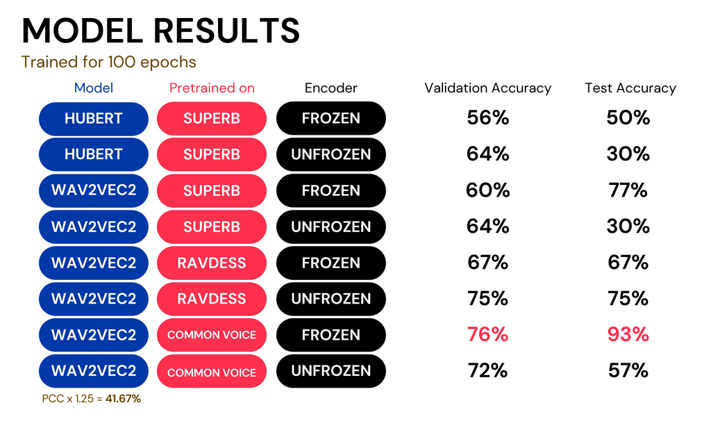

The following codeblocks were used to load the feature_extractor and model for audio classification from hugging_face. The preprocessing steps and settings for training were consistent for all models, the only thing that needs to be changed is the variable model_name, to change the model, and frozen to freeze or unfreeze the model's encoder.

The models were trained for 100 epochs, with the best model being saved automatically to a local directory. The criteria for the best model was validation accuracy.

Our best model (highest validation accuracy) was used to infer on the test set to calculate its precision, recall, F1-score, and confusion matrix.

```python
# Feel free to change the model among these:
# superb/wav2vec2-large-superb-er
# superb/hubert-large-superb-er
# ehcalabres/wav2vec2-lg-xlsr-en-speech-emotion-recognition
# facebook/wav2vec2-large-xlsr-53

model_name = "facebook/wav2vec2-large-xlsr-53"
```

```python
feature_extractor = AutoFeatureExtractor.from_pretrained(model_name)
model = AutoModelForAudioClassification.from_pretrained(model_name,
                                                        num_labels=num_labels,
                                                        label2id=label2id,
                                                        id2label=id2label,
                                                        ignore_mismatched_sizes=True)
```

```python
# For freezing or unfreezing
frozen = True
if frozen == True:
    model.freeze_feature_encoder()
```

```python
encoded_dataset = dataset.map(preprocess_function, remove_columns="audio", batched=True)
```

```python
encoded_dataset['test']
```

```python
training_args = TrainingArguments(
    output_dir='checkpoints',
    evaluation_strategy="steps",
    learning_rate=1e-4, #originally 3e-5. can play around
    per_device_train_batch_size=4,
    per_device_eval_batch_size=4,
    gradient_accumulation_steps=2,
    num_train_epochs=100, # set number of epochs here
    warmup_ratio=0.1,
    save_steps=10, # this will save multiple times (memory intensive)
    eval_steps=10,
    logging_steps=10,
    metric_for_best_model="accuracy",
    do_train = True,
    do_eval = True,
    do_predict = True,
    load_best_model_at_end=True,
    seed=0
)

trainer = Trainer(
    model=model,
    args=training_args,
    train_dataset=encoded_dataset["train"],
    eval_dataset=encoded_dataset["validation"],
    tokenizer=feature_extractor,
    compute_metrics=compute_metrics
)
```

```python
trainer.train()
```

```python
if frozen == True:
    title = f'{model_name}-frozen'
else:
    title = model_name

trainer.save_model(f'./ph_er_{title}_best')
```

```python
# Evaluating the Model

name = f'ph_er_{title}_best'

classifies = pipeline('audio-classification', model=name)

predictions = []
files = [i for i in sum([os.listdir(g) for g in glob.glob('./emotions/data/test/*/')], []) if i != '.DS_Store']

for file in files:
    file_path = glob.glob(f'./emotions/data/test/*/{file}')[0]
    try:
        scores = classifies(file_path)
        original_label = re.search(r'(.+)-\d+\.wav', file).group(1)
        predicted_label = scores[np.array([x['score'] for x in scores]).argmax()]['label']
        predictions.append([original_label, predicted_label])
        print(file_path)
        print(f'{original_label} =? {predicted_label}')
        print('--------------------------------------')
    except ValueError:
        print(f'Error processing file: {file_path}')

df_preds = pd.DataFrame(predictions, columns=['original', 'predicted'])

correct = len(df_preds[df_preds['original'] == df_preds['predicted']])
total = len(predictions)

accuracy = correct / total
print(f'Accuracy for {name}: {accuracy:.2f}')

# Calculate precision, recall, and F1-score
precision = precision_score(df_preds['original'], df_preds['predicted'], average='weighted')
recall = recall_score(df_preds['original'], df_preds['predicted'], average='weighted')
f1 = f1_score(df_preds['original'], df_preds['predicted'], average='weighted')

print(f'Precision: {precision:.2f}')
print(f'Recall: {recall:.2f}')
print(f'F1-score: {f1:.2f}')

# Generate confusion matrix
cm = confusion_matrix(df_preds['original'], df_preds['predicted'])
print('Confusion Matrix:')
print(cm)
```

## Clear checkpoints

```python
!rm -rf checkpoints
# delete checkpoints
```

# Results and Insights

[figure not shown]

To establish a baseline, we evaluated the performance of the two models already trained for speech emotion recognition (using RAVDESS and SuperB datasets) on our test set. The test accuracy ranged from 43% to 54%, indicating that the models were only marginally better than randomly choosing an emotion. Subsequently, we trained eight different models, each varying in architecture (Hubert or Wav2Vec2), pretrained model (SuperB, RAVDESS, or Common Voice), and encoder mode (frozen or unfrozen). In the context of transformer-based architectures, the encoder part is where the model learns different latent representations from the data which can be used for multiple downstream tasks. Freezing the encoder means relying on the latent representations from any pretraining before the checkpoint. Results revealed that the best-performing model was the one pretrained on the Common Voice dataset, which had not been fine-tuned for speech emotion recognition. While the test accuracy exceeded the validation accuracy, we acknowledge that we might have just been lucky with the test set. Interestingly, most models with unfrozen encoders exhibited lower test accuracies compared to their frozen counterparts, except for the combination of Wav2Vec2 and RAVDESS. This observation highlights the significance of learned latent representations in the models' performance.

## The Real Test: Using our Voices

We couldn't resist the opportunity to put our model to the test using our own voices. First, let's listen to Stevie's voice. Stevie has a very pleasant and composed tone, which aligns with the model's prediction of "well."

WELL

"Maraming Salamat!"

[interactive chart not shown]

Now, let's shift our focus to Ken's line. Interestingly, the model confidently predicted his voice as "sad." It's worth noting that Ken has a remarkable talent for mimicking voices, and it appears that he is equally skilled at capturing and conveying emotions. The accuracy of the model's prediction in this case further emphasizes Ken's ability to authentically express and evoke a sense of sadness through his voice.

SAD

“Lahat ng submissions ko late, babagsak na ata ako sa subject na to"

[interactive chart not shown]

Lastly, we turn to AJ, who is known for his even-tempered nature. The model exhibited confusion between "well" and "angry" when analyzing AJ's voice. This result suggests that the model has difficulty distinguishing subtle emotions or emotions that are not overtly intense. It makes sense since the model was primarily trained on lines delivered by actors who often portray highly emotional scenes. Therefore, when confronted with more nuanced emotional expressions, the model's performance may be less reliable.

ANGRY

“Ba’t naman ganyan? Namatay nanaman ang kernel!”

[interactive chart not shown]

# IMPLICATIONS AND FUTURE DIRECTIONS

[figure not shown]

In order to improve the accuracy of emotion recognition systems, we strongly recommend that future researchers delve into the use of pretrained models in languages other than English, such as Chinese or Russian. It is plausible that our intonations align more closely with those of Chinese or Russian speakers, potentially leading to enhanced model performance. By incorporating diverse linguistic and cultural contexts, we can gain a deeper understanding of how emotions are conveyed through speech across different languages.

[figure not shown]

Furthermore, we suggest incorporating audio recordings from live conversations, such as podcasts, into the training process. This approach allows the models to better capture the subtleties of not-so-extreme emotions. By exposing the models to a wider range of emotional expressions found in natural, unscripted conversations, we can improve their ability to recognize and interpret a broader spectrum of emotional states.

Moreover, future research should explore the integration of multimodal data, which includes facial expressions and gestures, to further enhance the accuracy of emotion recognition systems. By combining information from multiple modalities, we can obtain a more comprehensive understanding of human emotions, as these cues often work in tandem to convey emotional states. Integrating facial expressions and gestures alongside speech analysis can provide richer context and contribute to more accurate emotion recognition

# CONCLUSION

In conclusion, this project aimed to localize speech emotion recognition technology by fine-tuning existing models with Filipino-spoken passages. Throughout our study, we encountered several noteworthy findings. Firstly, existing speech emotion recognition (SER) models trained on English datasets did not perform well when tested using our dataset. However, by further training the models on our specific training data, we observed improved test accuracies.

It is important to highlight that the training data consisted of lines delivered by actors and actresses in Pinoy movies, where emotions were often exaggerated. As a result, the models struggled to accurately recognize not-so-extreme conveyances of emotions. Additionally, we noticed that passionate expressions of sadness were prone to being misclassified as anger.

Despite these challenges, our project has shed light on the intricacies of speech emotion recognition in the local context. By fine-tuning models with Filipino-spoken passages, we have made progress in enhancing speech emotion recognition capabilities specifically tailored to the Philippine context.

Our study serves as a stepping stone towards more personalized and empathetic AI interactions. As we continue to deepen our understanding of the complexities of human emotions in speech, we move closer to a future where AI can comprehend and respond to our emotions with greater accuracy and sensitivity.

# References

[1] Akçay, M. B., & Oğuz, K. (2020). Speech emotion recognition: Emotional models, databases, features, preprocessing methods, supporting modalities, and classifiers. Speech Communication, 116, 21-40. https://doi.org/10.1016/j.specom.2019.12.001

[2] Hugging Face. (n.d.). Hugging Face Documentation. Retrieved June 19, 2023, from https://huggingface.co/docs/transformers/index

[3] Emotion recognition in Greek speech using HuBERT. (n.d.). In Google Colaboratory. Retrieved June 19, 2023, from https://colab.research.google.com/github/m3hrdadfi/soxan/blob/main/notebooks/Emotion_recognition_in_Greek_speech_using_HuBERT.ipynb#scrollTo=Ylb2Z6Xke2ro